```python
import pandas as pd
import torch
from torch import nn
from torch.utils.data import DataLoader, Dataset

import gensim

from sklearn.model_selection import train_test_split
import sklearn.metrics as metrics

import matplotlib.pyplot as plt
import seaborn as sns
import numpy as np
from tqdm import tqdm
import gc
import os

import ssl
ssl._create_default_https_context = ssl._create_unverified_context
```

# Config

## Model training config

```python
LEARNING_RATE = 4e-4
WEIGHT_DECAY = 1e-2
BATCH_SIZE = 64
EPOCHS = 15

SEQUENCE_LEN = 64
CNN_FILTERS = 64
```

```python
DEVICE = torch.device("cuda" if torch.cuda.is_available() else "cpu")
```

# Data Preparation

## Load Data

```python
from google.colab import drive
drive.mount('/content/drive')
```

```python
df = pd.read_csv("./drive/MyDrive/twitter-suicidal-data.csv")
```

## Data Preprocessing

```python
!pip install emoji
import nltk
import emoji
import re

nltk.download(["stopwords", "punkt", "wordnet", "averaged_perceptron_tagger", "words"])
```

```
     ━━━━━━━━━━━━━━━━━━━━━━━━━━━━━━━━━━━━━━━━ 431.4/431.4 kB 2.6 MB/s eta 0:00:00
```

```
True
```

```python
import string
from nltk.tokenize import word_tokenize
from nltk.tag import pos_tag

stopwords = nltk.corpus.stopwords.words("english")
lemmatizer = nltk.stem.WordNetLemmatizer()
valid_words = set(nltk.corpus.words.words())

def nltk_pos_tagger(nltk_tag):
    if nltk_tag.startswith('J'):
        return 'a'
    elif nltk_tag.startswith('V'):
        return 'v'
    elif nltk_tag.startswith('N'):
        return 'n'
    elif nltk_tag.startswith('R'):
        return 'r'
    else:
        return 'n'

def remove_punctuation(text: str):
    return text.translate(str.maketrans('', '', string.punctuation))

def remove_numbers(text: str):
    return text.translate(str.maketrans('', '', string.digits))

def remove_urls(text: str):
    url_pattern = r'(http[s]?://\S+|www\.\S+)'
    return re.sub(url_pattern, '', text)

def remove_usernames(text: str):
    username_pattern = r'@\w+'
    return re.sub(username_pattern, '', text)

def convert_emoji_to_text(text: str):
    return emoji.replace_emoji(text, replace=' ')

def remove_whitespace(text: str):
    return re.sub(r'\s+', ' ', text).strip()

def remove_nonwords(text: str):
    return re.sub(r'[^\w\s]', '', text) #not sure, should remove hashtags?

def lemmatize(text: str):
    tokens = word_tokenize(text)
    # tokens = [token for token in tokens if token not in stopwords and token in valid_words]
    tokens = [token for token in tokens if token not in stopwords]
    pos_tagged = pos_tag(tokens)
    lemmatized_tokens = [lemmatizer.lemmatize(token, nltk_pos_tagger(tag)) for token, tag in pos_tagged]
    return lemmatized_tokens

def preprocess_data(text: str):
    text = remove_urls(text)
    text = remove_usernames(text)
    text = text.lower()
    text = remove_punctuation(text)
    text = remove_numbers(text)
    text = convert_emoji_to_text(text)
    text = remove_whitespace(text)
    tokens = lemmatize(text)
    return tokens
```

### Pros and Cons of Lowercasing

Pros:

1. Consistency: Ensuring that words like "Apple" and "apple" are treated as the same token, improving the model's ability to learn patterns.
2. Vocabulary Size Reduction: Reduces the vocabulary size, which simplifies the model and reduces memory usage.
3. Improved Generalization: Helps the model generalize better by treating different capitalizations of the same word as a single token.

Cons:

1. Loss of Information: Capitalization can carry important information (proper nouns, acronyms).
2. Ambiguity: Lowercasing can introduce ambiguity where words with different meanings are treated as the same ("US" vs "us").

Lowercasing is done to create uniformity in the text data, which helps in reducing complexity and improving the performance of the model by ensuring consistent handling of words. It is a trade-off between simplifying the text data and retaining potentially useful information.

### Pros and Cons of removing numbers

Pros:

1. Noise Reduction: Removes irrelevant numeric data that might not contribute to understanding the context or meaning.
2. Simplified Vocabulary: Reduces the vocabulary size, which can make the model simpler and more efficient.
3. Consistency: Ensures consistency in text representation, especially when numbers are not meaningful in the given context.

Cons:

1. Loss of Information: Numeric data can be important for context, such as dates, quantities, or specific identifiers ("COVID-19", "Chapter 4").
2. Reduced Context: In some cases, numbers provide essential context that can help in understanding the text better.
3. Ambiguity: Removing numbers can make it harder to differentiate between texts where numbers are crucial ("Room 101" vs "Room 102").

### Keeping hashtags

1. Contextual Significance: Hashtags often encapsulate the main topic or sentiment of the tweet, which can be crucial for understanding its meaning.
2. Keyword Indicators: Hashtags can act as important keywords that highlight specific issues, trends, or events related to the tweet's content.
3. Relevance to Suicidal Prediction: In the context of predicting suicidal tendencies, hashtags may contain terms directly related to mental health, distress signals, or support mechanisms (#depression, #help).
4. Social Media Context: Hashtags are a unique feature of social media language that carry meta-information about the tweet's content and should be preserved to maintain the integrity of the text.

```python
random_tweets = df["tweet"].sample(n=3, random_state=42)
for tweet in random_tweets:
    print("Original:", tweet)
    print("Preprocessed:", preprocess_data(tweet))
```

```
Original:  before i die i want to
Preprocessed: ['die', 'want']
Original: suicide the rational choice hi anonymous crowdrecently i have been contemplating suicide again and this time i feel like those thoughts are becoming more harder to dispel therefore i wanted to ask you guys for your thoughts here are my considerationsi dont think i can ever find a job becau…
Preprocessed: ['suicide', 'rational', 'choice', 'hi', 'anonymous', 'crowdrecently', 'contemplate', 'suicide', 'time', 'feel', 'like', 'thought', 'become', 'harder', 'dispel', 'therefore', 'want', 'ask', 'guy', 'thought', 'considerationsi', 'dont', 'think', 'ever', 'find', 'job', 'base', 'past', 'exp…
Original: invasive thoughts i have been depressed for a long timei amsure everyone on this thread hasi amon antidepressants and they dont seem to be working that welli ammaterially fairly successful married and have a kid but i keep getting invasive thoughts about killing myself it goes to show i gu…
Preprocessed: ['invasive', 'thought', 'depress', 'long', 'timei', 'amsure', 'everyone', 'thread', 'hasi', 'amon', 'antidepressant', 'dont', 'seem', 'work', 'welli', 'ammaterially', 'fairly', 'successful', 'marry', 'kid', 'keep', 'get', 'invasive', 'thought', 'kill', 'go', 'show', 'guess', 'mental', …
```

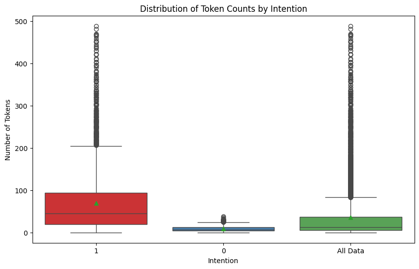

```python
df["processed_text"] = df["tweet"].map(preprocess_data)
df["num_tokens"] = df["processed_text"].map(len)

sub_df = df[df['num_tokens'] < 500]

df_alldata = sub_df.assign(intention='All Data')
plot_data = pd.concat([sub_df, df_alldata])

plt.figure(figsize=(10, 6))
sns.boxplot(x='intention', y='num_tokens', data=plot_data, palette="Set1", showmeans=True)
plt.title('Distribution of Token Counts by Intention')
plt.xlabel('Intention')
plt.ylabel('Number of Tokens')
plt.show()

df.drop(columns=["num_tokens", "processed_text"], inplace=True)
```

# Word2Vec - Word Embedding

### Handling Out-of-vocabulary words

1. Random Initialization
- Pros: Simple to implement; provides a vector for every word.
- Cons: May not capture any meaningful semantic information; adds randomness to the model.
2. Use a Special Token (for instance "UNK")
- Pros: Consistent handling of all unknown words; maintains model stability.
- Cons: Loss of specific word information; treats all unknown words the same, reducing nuance.
3. Character-level Embeddings
- Pros: Can generate vectors for any word; captures subword information, useful for morphologically rich languages.
- Cons: More complex to implement; may require more computational resources.
4. Back-off to a Similar Word
- Pros: Can provide a more meaningful vector than random initialization or a single "UNK" token.
- Cons: Identifying a "similar" word might be computationally intensive; still not the exact representation.
5. Train on a Larger Corpus or Update Vocabulary
- Pros: Reduces the number of OOV words by expanding the dictionary.
- Cons: Requires more data and computational resources; not always feasible.

```python
import gensim.downloader as api
print("\n".join(api.info()['models'].keys()))
```

```
fasttext-wiki-news-subwords-300
conceptnet-numberbatch-17-06-300
word2vec-ruscorpora-300
word2vec-google-news-300
glove-wiki-gigaword-50
glove-wiki-gigaword-100
glove-wiki-gigaword-200
glove-wiki-gigaword-300
glove-twitter-25
glove-twitter-50
glove-twitter-100
glove-twitter-200
__testing_word2vec-matrix-synopsis
```

```python
W2V_PATH = "word2vec-google-news-300.vectors.save"
if W2V_PATH is not None and os.path.exists(W2V_PATH):
    print("Loading Word2Vec model...")
    w2v_model = gensim.models.KeyedVectors.load(W2V_PATH, mmap='r')
    print("Word2Vec model is loaded.")
else:
    print("Downloading Word2Vec model...")
    w2v_model = api.load("word2vec-google-news-300")
    print("Word2vec model is downloaded.")
    if W2V_PATH is not None:
        print("\nSaving Word2Vec model...")
        w2v_model.save(W2V_PATH)
        print("Word2Vec model is saved.")
```

```
Downloading Word2Vec model...
[==================================================] 100.0% 1662.8/1662.8MB downloaded
Word2vec model is downloaded.

Saving Word2Vec model...
Word2Vec model is saved.
```

```python
EMBEDDING_VECTOR_DIM = w2v_model.vector_size
```

# Dataset

```python
class Twitter(Dataset):
    def __init__(self, dataframe: pd.DataFrame, w2v_model: gensim.models.KeyedVectors, sequence_len: int):
        self.dataframe = dataframe
        self.w2v_model = w2v_model
        self.max_sequence_len = sequence_len
        self.vector_size = w2v_model.vector_size
        self.df_token_col = "tokens"
        self._proc_dataset()
        self.len = len(self.dataframe)

    def __len__(self):
        return self.len

    def __getitem__(self, idx):
        return self.dataframe.iloc[idx]["vector"], self.dataframe.iloc[idx]["intention"]

    def get_vector_size(self):
        return self.vector_size

    def _proc_dataset(self):
        # Preprocess and return tokens list
        self.dataframe[self.df_token_col] = self.dataframe["tweet"].map(preprocess_data)

        # delete samples with empty tokens
        lwz = len(self.dataframe)
        self.dataframe = self.dataframe[self.dataframe[self.df_token_col].map(len) > 0]
        self.dataframe.reset_index(drop=True, inplace=True)
        print(f"Deleted 0-Len Samples: {lwz - len(self.dataframe)}")

        # Add padding
        self.dataframe[self.df_token_col] = self.dataframe[self.df_token_col].map(self._pad)

        # Get embedding's vectors
        self.dataframe["vector"] = self.dataframe[self.df_token_col].map(self._get_word_vectors)

    def _get_word_vectors(self, tokens: list) -> torch.tensor:
        # TODO: Return a 2D tensor for whole list of tokens, using vectors from w2v as explained on the description
        matrix = []
        for token in tokens:
            if token in self.w2v_model:
                matrix.append(self.w2v_model[token])
            else:
                matrix.append([0]*self.vector_size)
        return torch.tensor(matrix, dtype=torch.float)


    def _pad(self, tokens: list):
        # TODO: Add paddings (zero-vectors) into the end of sequence to reach the desired length
        if (len(tokens) >= self.max_sequence_len):
            tokens = tokens[:self.max_sequence_len]
        else:
            tokens = tokens + [""]*(self.max_sequence_len - len(tokens))
        return tokens

    def seq_report(self):
        length_all = self.dataframe[self.df_token_col].map(len).tolist()
        max_length = np.max(length_all)
        print(f"Sequence Length Report")
        print(f":::::MAX  LENGTH:::[{max_length:^5}]")
        print(f":::::MIN  LENGTH:::[{np.min(length_all):^5}]")
        print(f":::::MEAN LENGTH:::[{np.mean(length_all):^5}]")

        all_tokens = set()
        for token_set in self.dataframe[self.df_token_col].tolist():
            all_tokens = all_tokens.union(set(token_set))
        unique_tokens_count = len(all_tokens)
        valid_tokens = sum(1 if token in self.w2v_model else 0 for token in all_tokens)
        print("Sequence Tokenization Report")
        print(f":::::All Unique Tokens:::[{unique_tokens_count:^6}")
        print(f":::::All Valid Tokens:::[{valid_tokens:^6}")
        print(f":::::Valid Tokens:::[{round(100*valid_tokens/unique_tokens_count, 2):^5}%]")

    @staticmethod
    def _to_tensor(tokens: list):
        return torch.tensor(tokens, dtype=torch.float32)
```

# Prepare Data

## Split Data into train-valid

```python
# TODO: Split dataset into train-test split
from sklearn.model_selection import train_test_split
train_df, test_df = train_test_split(df, test_size=0.2, random_state=42)
```

## Create Datasets

```python
# TODO: create twitter dataset
train_dataset = Twitter(
    train_df,
    w2v_model,
    64
)
valid_dataset = Twitter(
    test_df,
    w2v_model,
    64
)

print(f"Train dataset length: {len(train_dataset)}")
print(f"Valid dataset length: {len(valid_dataset)}")
```

```
Deleted 0-Len Samples: 24
```

```
Deleted 0-Len Samples: 8
```

```
Train dataset length: 7271
Valid dataset length: 1816
```

```python
train_dataset_196 = Twitter(
    train_df,
    w2v_model,
    196
)
valid_dataset_196 = Twitter(
    test_df,
    w2v_model,
    196
)
```

```
Deleted 0-Len Samples: 24
```

```
Deleted 0-Len Samples: 8
```

# Model and Train

## Utils

```python
@torch.no_grad()
def model_eval(model, loader, loss_function, device: str = ['cuda', 'cpu', 'auto']):
    """Returns test_loss, test_acc"""
    test_loss = 0.0
    test_acc = 0.0
    total_samples = 0
    correct_samples = 0

    if device == "auto":
        device = torch.device("cuda" if torch.cuda.is_available() else "cpu")

    model = model.to(device)
    itr = tqdm(loader, total=len(loader), leave=True)

    for inputs, labels in itr:
        # TODO: move model's inputs to `device`
        inputs, labels = inputs.to(device), labels.to(device)

        # TODO: use model's forward pass to generate outputs
        outputs = model(inputs)

        # TODO: calculate model's loss
        loss = loss_function(outputs, labels)
        test_loss += loss.item()

        # TODO: calculate/update model's accuracy
        _, predicted = torch.max(outputs, 1)
        correct_samples += (predicted == labels).sum().item()
        total_samples += labels.size(0)
        test_acc = correct_samples / total_samples

        itr.set_description("(Eval)")
        itr.set_postfix(
            loss=round(loss.item(), 5),
            accuracy=round(test_acc, 5),
        )
    test_loss /= len(itr)
    return test_loss, test_acc
```

```python
def train_model(
        model,
        batch_size,
        loss_function,
        optimizer,
        epochs,
        train_set,
        valid_set,
        device: str = ['cuda', 'cpu', 'auto'],
):

    if device == "auto":
        device = torch.device("cuda" if torch.cuda.is_available() else "cpu")
    model.to(device)

    train_losses = []
    train_accs = []

    valid_losses = []
    valid_accs = []

    # TODO: create dataloaders from datasets
    train_loader = DataLoader(train_set, batch_size=batch_size, shuffle=True)
    valid_loader = DataLoader(valid_set, batch_size=batch_size, shuffle=False)


    for epoch in range(epochs):
        model.train()
        epoch_loss = 0
        epoch_acc = 0
        total_samples = 0
        correct_samples = 0

        itr = tqdm(train_loader, total=len(train_loader), leave=True, desc=f"(Training) Epoch [{epoch + 1}/{epochs}]")

        for idx, (inputs, labels) in enumerate(itr, start=1):
            # TODO: move model's inputs to `device`
            inputs, labels = inputs.to(device), labels.to(device)

            # TODO: use model's forward pass to generate outputs
            outputs = model(inputs)

            # TODO: process model's predictipns and calculate/update accuracy
            _, predicted = torch.max(outputs, 1)
            correct_samples += (predicted == labels).sum().item()
            total_samples += labels.size(0)
            epoch_acc = correct_samples / total_samples

            # TODO: calculate model's loss and update epoch's loss
            loss = loss_function(outputs, labels)
            epoch_loss += loss.item()

            # TODO: 1. clear optimizer's state and zero prev grads,
            # TODO: 2. backward calculated loss
            # TODO: 3. step optimizer

            optimizer.zero_grad()
            loss.backward()
            optimizer.step()

            itr.set_description(f"(Training) Epoch [{epoch + 1}/{epochs}]")
            itr.set_postfix(
                loss=round(loss.item(), 5),
                accuracy=round(epoch_acc, 5),
            )

        epoch_loss /= len(itr)

        model.eval()
        valid_loss, valid_acc = model_eval(
            model=model,
            loader=valid_loader,
            loss_function=loss_function,
            device=device
        )

        # TODO: update statistics regaurding model's loss and acc in training or validation phases
        train_losses.append(epoch_loss)
        train_accs.append(epoch_acc)
        valid_losses.append(valid_loss)
        valid_accs.append(valid_acc)

        print(f"Epoch {epoch+1}/{epochs} - "
              f"Train Loss: {epoch_loss:.4f}, Train Acc: {epoch_acc:.4f}, "
              f"Valid Loss: {valid_loss:.4f}, Valid Acc: {valid_acc:.4f}\n")

    history = {
      "train_loss": train_losses,
      "train_acc": train_accs,

      "valid_loss": valid_losses,
      "valid_acc": valid_accs,
    }
    return history
```

```python
def trend_plot_helper(pobj):
    plt.figure(figsize=(5*len(pobj), 5))
    for idx, (titler, plots) in enumerate(pobj.items(), start=1):
        plt.subplot(1, len(pobj), idx)
        for label, trend in plots:
            plt.plot(range(1, len(trend)+1), trend, label=label)
        yt, xt = titler.split(' - ')
        plt.xlabel(xt)
        plt.ylabel(yt)
        plt.legend()
```

```python
@torch.no_grad()
def generate_confusion_matrix(model, dataset, device='auto'):
    if device == 'auto':
        device = torch.device("cuda" if torch.cuda.is_available() else "cpu")
    model = model.to(device)

    loader = DataLoader(dataset, batch_size=32, shuffle=False)
    itr = tqdm(loader, leave=False, desc="Generate data")

    # TODO: code here, you must fill variables below
    # TODO: labels = true labels from the dataset
    # TODO: predicted = labels predicted by the model

    true_labels = []
    predicted_labels = []

    for inputs, labels in itr:
        inputs = inputs.to(device)
        labels = labels.to(device)

        outputs = model(inputs)
        _, predicted = torch.max(outputs, 1)
        true_labels.extend(labels.cpu().numpy())
        predicted_labels.extend(predicted.cpu().numpy())

    cm = metrics.confusion_matrix(
        y_true=true_labels,
        y_pred=predicted_labels,
    )

    plt.figure(figsize=(10,10))
    sns.heatmap(cm, cmap='Blues', annot=True, cbar=False, fmt=".0f",)
    plt.xlabel('Predicted Label', labelpad=20)
    plt.ylabel('True Label', labelpad=20)
    plt.title('Confusion Matrix', fontsize=30)

    recall = metrics.recall_score(y_true=true_labels, y_pred=predicted_labels, average='macro')
    f1 = metrics.f1_score(y_true=true_labels, y_pred=predicted_labels, average='macro')
    precision = metrics.precision_score(y_true=true_labels, y_pred=predicted_labels, average='macro')
    report = metrics.classification_report(y_true=true_labels, y_pred=predicted_labels)

    return {'recall': recall, 'f1': f1, 'precision': precision, 'report': report}
```

## Model's Network

```python
import torch.nn.functional as F
import torch
import torch.nn as nn

class CNN(nn.Module):
    def __init__(self, context_window=64, regularization=False):
        super(CNN, self).__init__()
        self.regularization = regularization
        self.context_window = context_window

        self.conv1 = nn.Conv1d(in_channels=self.context_window, out_channels=64, kernel_size=3, padding=1)
        self.conv2 = nn.Conv1d(in_channels=self.context_window, out_channels=64, kernel_size=5, padding=2)
        self.conv3 = nn.Conv1d(in_channels=self.context_window, out_channels=64, kernel_size=7, padding=3)

        self.dropout = nn.Dropout(0.5)

        self.conv4 = nn.Conv1d(in_channels=64, out_channels=128, kernel_size=3, padding=1)
        self.conv5 = nn.Conv1d(in_channels=64, out_channels=128, kernel_size=5, padding=2)
        self.conv6 = nn.Conv1d(in_channels=64, out_channels=128, kernel_size=7, padding=3)

        self.bn4 = nn.BatchNorm1d(128)
        self.bn5 = nn.BatchNorm1d(128)
        self.bn6 = nn.BatchNorm1d(128)

        self.maxpool = nn.MaxPool1d(kernel_size=2)
        self.global_avg_pool = nn.AdaptiveAvgPool1d(1)

        self.flatten = nn.Flatten()

        conv_output_size = 128 * 3
        self.fc1 = nn.Linear(in_features=conv_output_size, out_features=128)
        self.fc2 = nn.Linear(in_features=128, out_features=2)

    def forward(self, x):

        x1 = F.relu(self.conv1(x))
        x2 = F.relu(self.conv2(x))
        x3 = F.relu(self.conv3(x))

        if (self.regularization):
          x1 = self.dropout(x1)
          x2 = self.dropout(x2)
          x3 = self.dropout(x3)

        x4 = None
        x5 = None
        x6 = None

        if (self.regularization):
          x4 = F.relu(self.bn4(self.conv4(x1)))
          x5 = F.relu(self.bn5(self.conv5(x2)))
          x6 = F.relu(self.bn6(self.conv6(x3)))

        else:
          x4 = F.relu(self.conv4(x1))
          x5 = F.relu(self.conv5(x2))
          x6 = F.relu(self.conv6(x3))

        if (self.regularization):
          x4 = self.dropout(x4)
          x5 = self.dropout(x5)
          x6 = self.dropout(x6)

        x4 = self.maxpool(x4)
        x5 = self.maxpool(x5)
        x6 = self.maxpool(x6)

        x4 = self.global_avg_pool(x4)
        x5 = self.global_avg_pool(x5)
        x6 = self.global_avg_pool(x6)

        x = torch.cat((x4, x5, x6), dim=1)

        x = self.flatten(x)

        x = F.relu(self.fc1(x))
        x = self.fc2(x)

        return x
```

### Adam Optimizer

Adaptive Moment Estimation Combines the benefits of two other extensions of stochastic gradient descent (SGD). Specifically, Adam computes adaptive learning rates for each parameter.

- Key Features:
  - Adaptive Learning Rate: Adjusts learning rate individually for each parameter.
  - Momentum: Uses running averages of both the gradients and their squares (first and second moments).

Difference with SGD:

SGD:

- Learning Rate: Fixed or decayed manually over time.
- Momentum: Can be added, but it's not inherent.
- Convergence: Slower and more sensitive to initial learning rate.

Adam:

- Learning Rate: Adaptive, reducing the need for manual tuning.
- Momentum: Inherent, uses first and second moments of gradients.
- Convergence: Faster and more robust to noisy data and sparse gradients.

### Cross Entropy Loss for Classification Problems

1. Suitability: Cross Entropy Loss is well suited for multi class classification tasks. It penalizes predictions that are confidently wrong more heavily.
2. Probability Interpretation: It compares the predicted probabilities of each class with the true distribution of classes. It provides a measure of how well the model's predicted probabilities match the true distribution.
3. Differentiability: It's differentiable, making it suitable for gradient-based optimization algorithms like backpropagation.
4. Overall Performance: It has been shown to work well in various classification tasks, including suicidal prediction, by effectively penalizing incorrect predictions and guiding the model towards better performance.

### Train Test partitioning

A 20% test partition is commonly used and generally provides a reasonable balance between training and testing data. It provides enough instances for evaluating model performance without sacrificing too much training data. It allows for robust evaluation of the model's generalization performance on unseen data. it helps mitigate the risk of overfitting by providing a larger portion of data for training.

### Kernel size

1. Feature Extraction:
   - Low Kernel Size: Captures fine-grained details and local patterns.
   - High Kernel Size: Encodes broader spatial information and global patterns.
2. Local vs. Global Information:
   - Low kernel sizes focus on local neighborhoods, extracting fine details.
   - High kernel sizes consider larger regions, capturing more global features.
3. Model Complexity:
   - Low kernel sizes result in fewer parameters and less computational complexity.
   - High kernel sizes increase model capacity and computational requirements.
4. Interpretation:
   - A low kernel size means the model concentrates on intricate details, suitable for tasks with small-scale features.
   - A high kernel size implies a broader scope, beneficial for detecting larger patterns or structures in the data.

### Output Reduction in Convolutional Layers

- Pros:
  - Dimensionality Reduction: Applying pooling operations like max pooling or global average pooling after convolutional layers reduces the spatial dimensions, focusing on the most informative features.
  - Non-linearity: Convolutional layers followed by activation functions introduce non-linearities, enhancing the model's capacity to capture complex patterns.
  - Hierarchical Feature Extraction: Convolutional layers progressively extract higher-level features, enabling the model to learn hierarchical representations.
- Advantages Over Feedforward Layers:
  - Spatial Hierarchical Representation: Convolutional layers capture spatial relationships in the input data, facilitating the extraction of local patterns.
  - Parameter Efficiency: Fewer parameters are required compared to fully connected layers, reducing the risk of overfitting and computational complexity.
  - Translation Invariance: Convolutional layers exploit local receptive fields, making the model more robust to translations in the input data.
- Choice Justification:
  - Performance: Convolutional layers are effective in capturing spatial dependencies and reducing dimensionality, contributing to improved performance and generalization.
  - Feature Abstraction: By abstracting features hierarchically, convolutional layers enable the model to learn more discriminative representations, enhancing its predictive capability.

### Setting Context Window Larger than Input Tweets

Pros:

- Uniformity: Ensures all inputs are processed with a consistent context window, simplifying model architecture.
- No Truncation: Prevents loss of information from longer texts, as the context window will always be sufficient.

Cons:

- Wasted Resources: Excessive padding for shorter texts can lead to inefficient use of computational resources and memory.
- Noise Introduction: Too much padding can introduce irrelevant information, potentially degrading model performance.
- Overfitting Risk: Larger context windows may increase the number of parameters, raising the risk of overfitting, especially with limited data.

## Training

### context window = 64, regularization = False, batch_size = 32, learning_rate = 0.001

```python
model = CNN()
batch_size = 32
loss_function = nn.CrossEntropyLoss()
optimizer = torch.optim.Adam(model.parameters(), lr=0.001)
epochs = 10

cnn_model_train_history = train_model(
    model=model,
    batch_size=batch_size,
    loss_function=loss_function,
    optimizer=optimizer,
    epochs=epochs,
    train_set=train_dataset,
    valid_set=valid_dataset,
    device='cuda' if torch.cuda.is_available() else 'cpu'
)
```

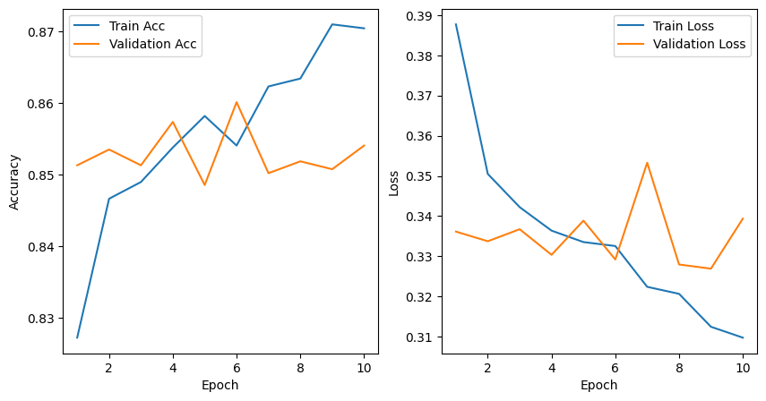

```python
trend_plot_helper(
    {
        "Accuracy - Epoch": [
            ("Train Acc", cnn_model_train_history["train_acc"]),
            ("Validation Acc", cnn_model_train_history["valid_acc"]),
        ],
        "Loss - Epoch": [
            ("Train Loss", cnn_model_train_history["train_loss"]),
            ("Validation Loss", cnn_model_train_history["valid_loss"])
        ]
    }
)
```

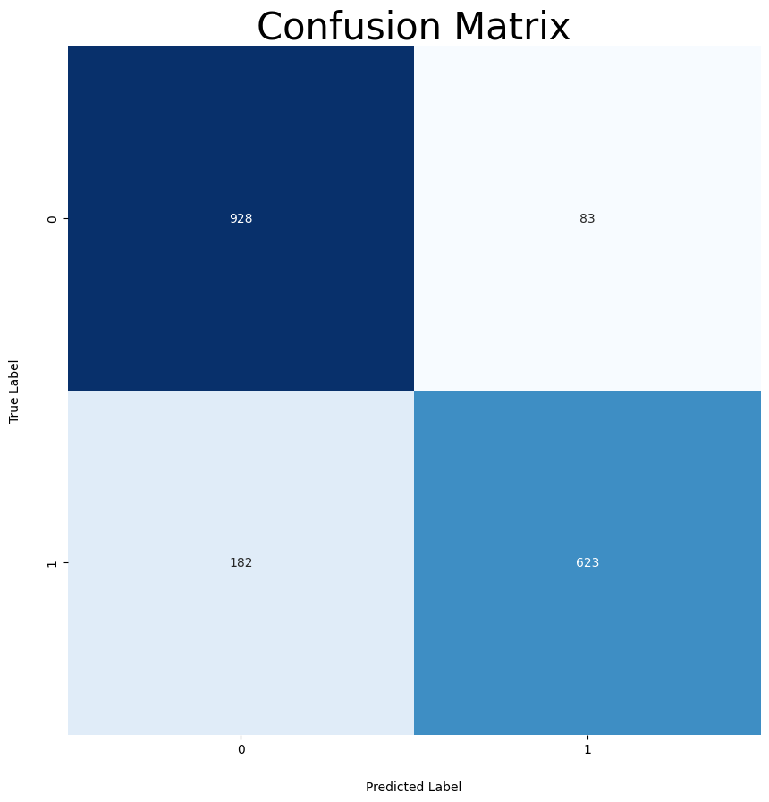

```python
cnn_model_report = generate_confusion_matrix(
    model=model,
    dataset=valid_dataset,
)
```

```python
print(f"Recall:    {cnn_model_report['recall']:.3f}")
print(f"F1:        {cnn_model_report['f1']:.3f}")
print(f"Precision: {cnn_model_report['precision']:.3f}")
print(cnn_model_report['report'])
```

```
Recall:    0.846
F1:        0.850
Precision: 0.859
              precision    recall  f1-score   support

           0       0.84      0.92      0.88      1011
           1       0.88      0.77      0.82       805

    accuracy                           0.85      1816
   macro avg       0.86      0.85      0.85      1816
weighted avg       0.86      0.85      0.85      1816
```

### context window = 64, regularization = False, batch_size = 64, learning_rate = 0.02

```python
model = CNN()
batch_size = 64
loss_function = nn.CrossEntropyLoss()
optimizer = torch.optim.Adam(model.parameters(), lr=0.02)
epochs = 10

cnn_model_train_history = train_model(
    model=model,
    batch_size=batch_size,
    loss_function=loss_function,
    optimizer=optimizer,
    epochs=epochs,
    train_set=train_dataset,
    valid_set=valid_dataset,
    device='cuda' if torch.cuda.is_available() else 'cpu'
)
```

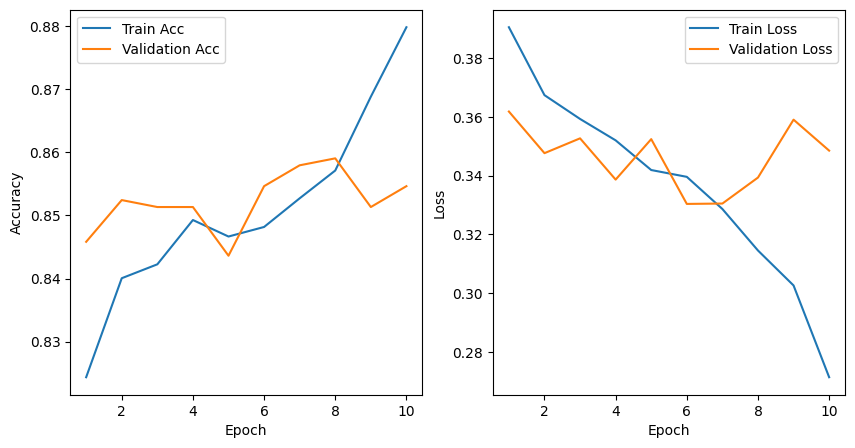

```python
trend_plot_helper(
    {
        "Accuracy - Epoch": [
            ("Train Acc", cnn_model_train_history["train_acc"]),
            ("Validation Acc", cnn_model_train_history["valid_acc"]),
        ],
        "Loss - Epoch": [
            ("Train Loss", cnn_model_train_history["train_loss"]),
            ("Validation Loss", cnn_model_train_history["valid_loss"])
        ]
    }
)
```

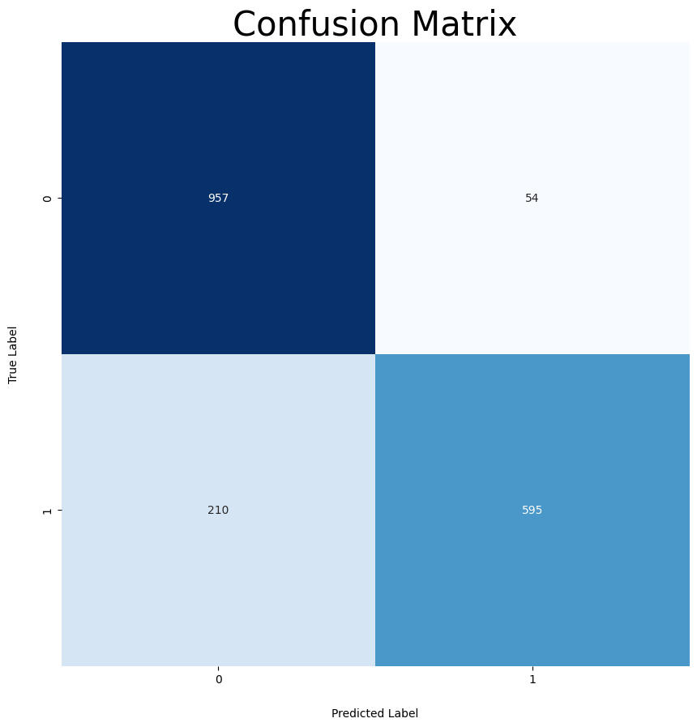

```python
cnn_model_report = generate_confusion_matrix(
    model=model,
    dataset=valid_dataset,
)
```

```python
print(f"Recall:    {cnn_model_report['recall']:.3f}")
print(f"F1:        {cnn_model_report['f1']:.3f}")
print(f"Precision: {cnn_model_report['precision']:.3f}")
print(cnn_model_report['report'])
```

```
Recall:    0.843
F1:        0.849
Precision: 0.868
              precision    recall  f1-score   support

           0       0.82      0.95      0.88      1011
           1       0.92      0.74      0.82       805

    accuracy                           0.85      1816
   macro avg       0.87      0.84      0.85      1816
weighted avg       0.86      0.85      0.85      1816
```

### context window = 196, regularization = False, batch_size = 32, learning_rate = 0.001

```python
model = CNN(196)
batch_size = 32
loss_function = nn.CrossEntropyLoss()
optimizer = torch.optim.Adam(model.parameters(), lr=0.001)
epochs = 10

cnn_model_train_history = train_model(
    model=model,
    batch_size=batch_size,
    loss_function=loss_function,
    optimizer=optimizer,
    epochs=epochs,
    train_set=train_dataset_196,
    valid_set=valid_dataset_196,
    device='cuda' if torch.cuda.is_available() else 'cpu'
)
```

```
  return F.conv1d(input, weight, bias, self.stride,
```

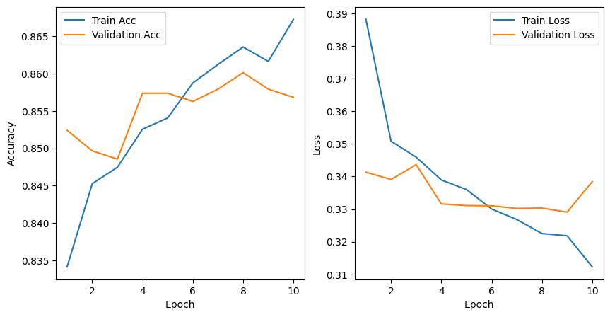

```python
trend_plot_helper(
    {
        "Accuracy - Epoch": [
            ("Train Acc", cnn_model_train_history["train_acc"]),
            ("Validation Acc", cnn_model_train_history["valid_acc"]),
        ],
        "Loss - Epoch": [
            ("Train Loss", cnn_model_train_history["train_loss"]),
            ("Validation Loss", cnn_model_train_history["valid_loss"])
        ]
    }
)
```

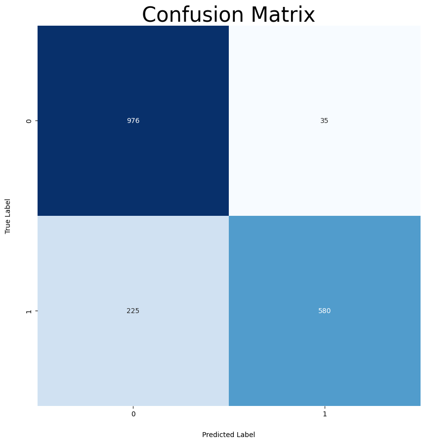

```python
cnn_model_report = generate_confusion_matrix(
    model=model,
    dataset=valid_dataset_196,
)
```

```python
print(f"Recall:    {cnn_model_report['recall']:.3f}")
print(f"F1:        {cnn_model_report['f1']:.3f}")
print(f"Precision: {cnn_model_report['precision']:.3f}")
print(cnn_model_report['report'])
```

```
Recall:    0.843
F1:        0.850
Precision: 0.878
              precision    recall  f1-score   support

           0       0.81      0.97      0.88      1011
           1       0.94      0.72      0.82       805

    accuracy                           0.86      1816
   macro avg       0.88      0.84      0.85      1816
weighted avg       0.87      0.86      0.85      1816
```

### Changing the size of context window

changing the size of the context window slightly improves the precision and accuracy of the model. Increasing the context window size from 64 to 196 likely improved precision and accuracy because the model could capture more context and dependencies within the input text, leading to better feature extraction and more informed decision-making.

### context window = 64, regularization = True, batch_size = 32, learning_rate = 0.001

```python
model = CNN(64, True)
batch_size = 32
loss_function = nn.CrossEntropyLoss()
optimizer = torch.optim.Adam(model.parameters(), lr=0.001)
epochs = 10

cnn_model_train_history = train_model(
    model=model,
    batch_size=batch_size,
    loss_function=loss_function,
    optimizer=optimizer,
    epochs=epochs,
    train_set=train_dataset,
    valid_set=valid_dataset,
    device='cuda' if torch.cuda.is_available() else 'cpu'
)
```

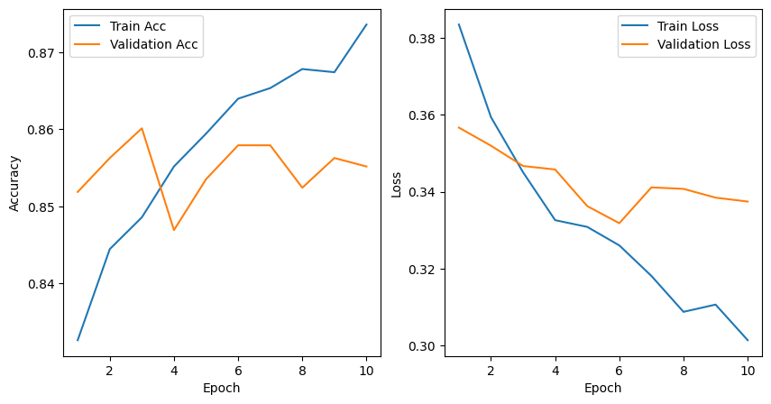

```python
trend_plot_helper(
    {
        "Accuracy - Epoch": [
            ("Train Acc", cnn_model_train_history["train_acc"]),
            ("Validation Acc", cnn_model_train_history["valid_acc"]),
        ],
        "Loss - Epoch": [
            ("Train Loss", cnn_model_train_history["train_loss"]),
            ("Validation Loss", cnn_model_train_history["valid_loss"])
        ]
    }
)
```

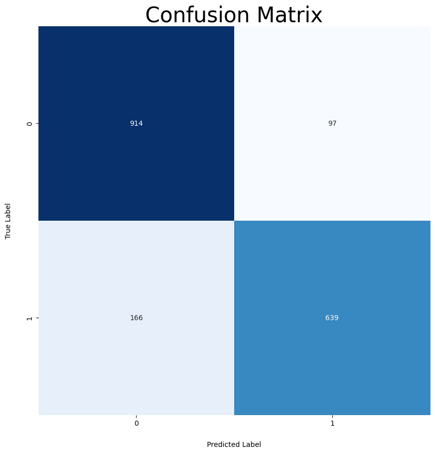

```python
cnn_model_report = generate_confusion_matrix(
    model=model,
    dataset=valid_dataset,
)
```

```python
print(f"Recall:    {cnn_model_report['recall']:.3f}")
print(f"F1:        {cnn_model_report['f1']:.3f}")
print(f"Precision: {cnn_model_report['precision']:.3f}")
print(cnn_model_report['report'])
```

```
Recall:    0.849
F1:        0.852
Precision: 0.857
              precision    recall  f1-score   support

           0       0.85      0.90      0.87      1011
           1       0.87      0.79      0.83       805

    accuracy                           0.86      1816
   macro avg       0.86      0.85      0.85      1816
weighted avg       0.86      0.86      0.85      1816
```

### context window = 196, regularization = True, batch_size = 32, learning_rate = 0.001

```python
model = CNN(196, True)
batch_size = 32
loss_function = nn.CrossEntropyLoss()
optimizer = torch.optim.Adam(model.parameters(), lr=0.001)
epochs = 10

cnn_model_train_history = train_model(
    model=model,
    batch_size=batch_size,
    loss_function=loss_function,
    optimizer=optimizer,
    epochs=epochs,
    train_set=train_dataset_196,
    valid_set=valid_dataset_196,
    device='cuda' if torch.cuda.is_available() else 'cpu'
)
```

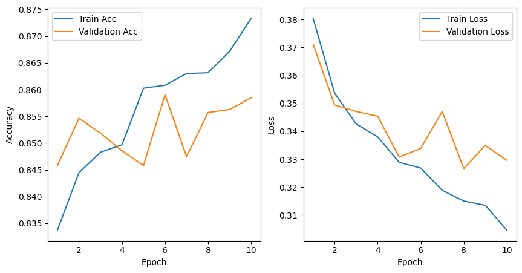

```python
trend_plot_helper(
    {
        "Accuracy - Epoch": [
            ("Train Acc", cnn_model_train_history["train_acc"]),
            ("Validation Acc", cnn_model_train_history["valid_acc"]),
        ],
        "Loss - Epoch": [
            ("Train Loss", cnn_model_train_history["train_loss"]),
            ("Validation Loss", cnn_model_train_history["valid_loss"])
        ]
    }
)
```

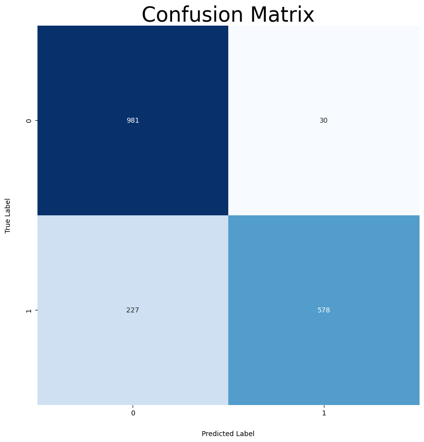

```python
cnn_model_report = generate_confusion_matrix(
    model=model,
    dataset=valid_dataset_196,
)
```

```python
print(f"Recall:    {cnn_model_report['recall']:.3f}")
print(f"F1:        {cnn_model_report['f1']:.3f}")
print(f"Precision: {cnn_model_report['precision']:.3f}")
print(cnn_model_report['report'])
```

```
Recall:    0.844
F1:        0.851
Precision: 0.881
              precision    recall  f1-score   support

           0       0.81      0.97      0.88      1011
           1       0.95      0.72      0.82       805

    accuracy                           0.86      1816
   macro avg       0.88      0.84      0.85      1816
weighted avg       0.87      0.86      0.85      1816
```